# a3_task3_satie_airame.Rmd

Satie Airame

11/1/2020

## Santa Barbara Urchins

### Data: Reed, D. 2020. SBC LTER: Reef: Long-term experiment: Kelp removal: Urchin size frequency distribution ver 20. Environmental Data Initiative.

Read in the urchin.csv data and convert to lower_snake_case.

```r
urchins <- read_csv(here("data", "urchins.csv")) %>%
  clean_names()
```

#### Compare the distribution of sizes between purple and red urchins using faceted histogram and boxplot.

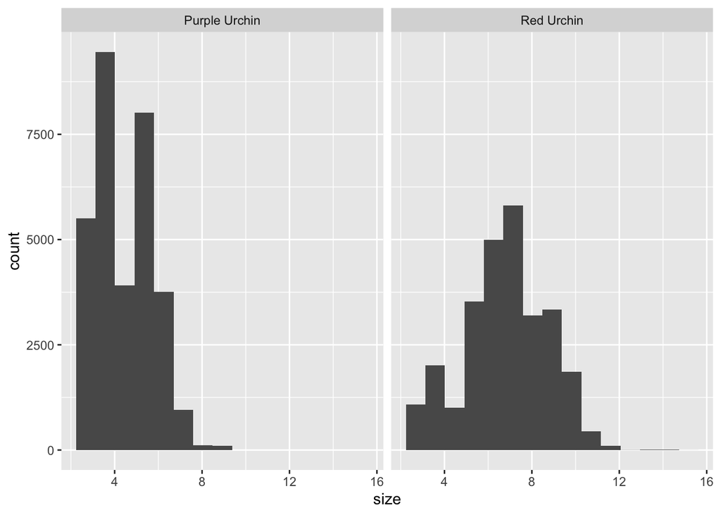

```r
ggplot(data = urchins, aes(x = size)) +
  geom_histogram(bins = 15) +
  facet_wrap(~common_name)
```

#### Purple urchins demonstrate a slightly positively skewed size distribution (measured as diameter in cm). Red urchins demonstrate a normal distribution with slightly larger sizes than purple urchins.

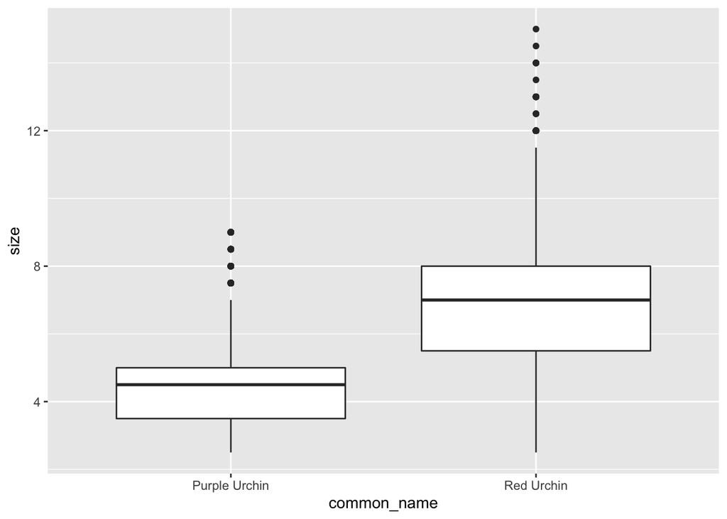

```r
ggplot(data = urchins, aes(x = common_name, y = size)) +
  geom_boxplot()
```

#### The average diameter of purple urchins is smaller than red urchins. The standard deviation of diameter for red urchins is greater than for purple urchins.

#### Create a summary table of mean, median, standard deviation, and sample size of diameters of purple urchins and red urchins.

```r
urchin_stats <- urchins %>%
  group_by(common_name) %>%
  summarize(mean_size = mean(size),
            median_size = median(size),
            sd_size = sd(size),
            n = n())
urchin_stats
```

```
## # A tibble: 2 x 5
##   common_name   mean_size median_size sd_size     n
##   <chr>             <dbl>       <dbl>   <dbl> <int>
## 1 Purple Urchin      4.47         4.5    1.18 31805
## 2 Red Urchin         6.78         7      1.89 27408
```

### Filter purple_urchins, convert data to class “Date”, create new column “year”, create new column “site_full” with full name of sites.

```r
purple_urchins <- urchins %>%
  filter(common_name == "Purple Urchin") %>%
  mutate(date_new = mdy(date)) %>%
  mutate(year_new = year(date_new)) %>%
  mutate(site_full = case_when(
    site == "NAPL" ~ "Naples Reef",
    site == "AQUE" ~ "Arroyo Quemado Reef",
    site == "CARP" ~ "Carpinteria Reef",
    site == "MOHK" ~ "Mohawk Reef",
    site == "IVEE" ~ "Isla Vista Reef"))
```

### Create summary table of total number purple urchins observed by site and year_new.

```r
purple_urchins_stats <- purple_urchins %>%
  count(site,year_new)
purple_urchins_stats
```

```
## # A tibble: 61 x 3
##    site  year_new     n
##    <chr>    <dbl> <int>
##  1 AQUE      2008    67
##  2 AQUE      2009   926
##  3 AQUE      2010   921
##  4 AQUE      2011   887
##  5 AQUE      2012   764
##  6 AQUE      2013   434
##  7 AQUE      2014   410
##  8 AQUE      2015   400
##  9 AQUE      2016   342
## 10 AQUE      2017   406
## # … with 51 more rows
```

### Make exploratory graph of counts of purple urchins recorded at each site over time for the years in the study.

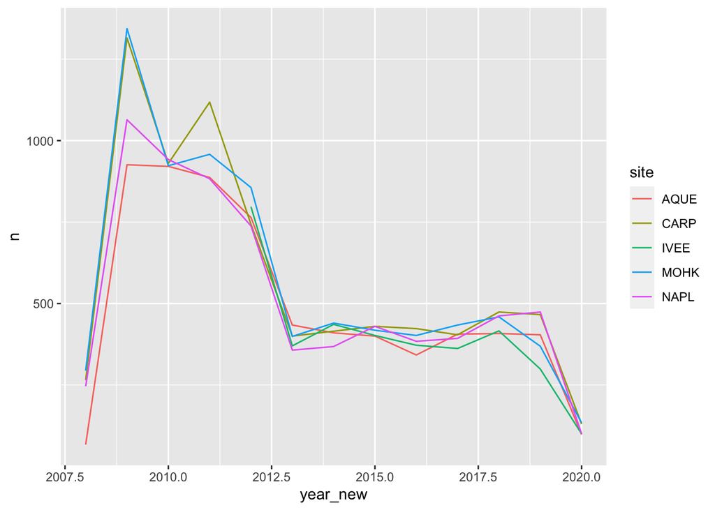

```r
ggplot(data = purple_urchins_stats, aes(x=year_new, y=n))+
  geom_line(aes(color = site))
```